# Continuous random variables: live R demonstrations

POLI 210 - September 30, 2026

Author

Brad LeVeck

## Using this document

Open this QMD in RStudio. Run a numbered demonstration with its chunk’s green arrow. **Every numbered chunk is independent:** it defines its own inputs, functions, and seed. You can jump between sections without running an earlier chunk. The code uses base R. Rendering uses knitr and rmarkdown.

The HTML shows saved output; edit and run the QMD for live demonstrations. All examples are hypothetical. The bargaining population and forecast parameters differ from B2. No student data or homework solutions appear here.

The integral notation in class means accumulating probability over an interval. These demonstrations use geometry, CDFs, or simulation to do the calculations. **No hand integration is needed.**

## 1. Waiting times and rectangle areas

Model the waiting time until an outreach worker arrives as $T\sim\operatorname{Unif}(0,10)$ minutes. This is a deliberately simple model, not an empirical claim about arrival times.

**Predict:** What fraction of waits fall between 2 and 5 minutes?

```r
set.seed(93001)
n_sim <- 50000
waits <- runif(n_sim, min = 0, max = 10)
exact_interval <- punif(5, 0, 10) - punif(2, 0, 10)
data.frame(quantity = c("P(2 <= T <= 5)", "E[T]", "Var(T)"),
           exact = c(exact_interval, 5, 100 / 12),
           simulated = c(mean(waits >= 2 & waits <= 5),
                         mean(waits), var(waits)))
```

```
        quantity    exact simulated
1 P(2 <= T <= 5) 0.300000  0.300340
2           E[T] 5.000000  5.006391
3         Var(T) 8.333333  8.334221
```

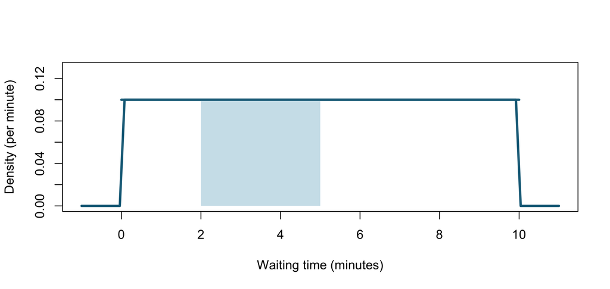

```r
curve(dunif(x, 0, 10), from = -1, to = 11,
      ylim = c(0, .13), col = "#176B87", lwd = 3,
      xlab = "Waiting time (minutes)", ylab = "Density (per minute)")
rect(2, 0, 5, .1, col = "#CEE3EB", border = NA)
segments(0, .1, 10, .1, col = "#176B87", lwd = 3)
```

```r
epsilon <- c(.5, .1, .01)
center <- 5
narrow_intervals <- data.frame(
  lower = center - epsilon,
  upper = center + epsilon,
  width = 2 * epsilon,
  probability = punif(center + epsilon, 0, 10) -
                punif(center - epsilon, 0, 10)
)
narrow_intervals$probability_per_minute <-
  narrow_intervals$probability / narrow_intervals$width
narrow_intervals
```

```
  lower upper width probability probability_per_minute
1  4.50  5.50  1.00       0.100                    0.1
2  4.90  5.10  0.20       0.020                    0.1
3  4.99  5.01  0.02       0.002                    0.1
```

```r
c(density_at_five = dunif(5, 0, 10),
  probability_at_or_below_five = punif(5, 0, 10))
```

```
             density_at_five probability_at_or_below_five
                         0.1                          0.5
```

The rectangle has width 3 minutes and height 0.1 per minute: area 0.3. `&` applies both inequalities to every draw. `&&` is not the vector operation we need here. Change `n_sim` to 500: the probability model and its variance stay fixed, but the simulation becomes less precise.

In the shrinking-interval table, probabilities approach zero while probability divided by width remains 0.1 per minute. That local rate is `dunif(5, 0, 10)`. It does not mean $P(T=5)=0.1$. `punif(5, 0, 10)` returns a probability for the implicit interval $(-\infty,5]$, which here is the same event as $0\le T\le5$.

For a density continuous at $x$, this generalizes to

$$f_X(x)=\lim_{\epsilon\downarrow0}
\frac{P(x-\epsilon\le X\le x+\epsilon)}{2\epsilon}.$$

Some authors call a density $p(x)$ instead of $f_X(x)$. Check what the function represents, rather than assuming its letter means point probability.

## 2. Optional: a sloping density without antiderivatives

Suppose a different waiting-time model has density $f(t)=t/50$ on $[0,10]$. The whole triangle has area one. Its CDF within the support is $F(t)=t^2/100$, the area of a triangle of base $t$ and height $t/50$.

The supplied sampling transformation $T=10\sqrt U$, for $U\sim\operatorname{Unif}(0,1)$, has that CDF. Understanding the density and CDF is the main task; deriving this sampling method is optional.

```r
set.seed(93002)
n_sim <- 50000
waits <- 10 * sqrt(runif(n_sim))
exact_interval <- (5^2 - 2^2) / 100
trapezoid_area <- (5 - 2) * ((2 / 50) + (5 / 50)) / 2
data.frame(method = c("CDF difference", "Trapezoid area", "Simulation"),
           probability = c(exact_interval, trapezoid_area,
                           mean(waits >= 2 & waits <= 5)))
```

```
          method probability
1 CDF difference     0.21000
2 Trapezoid area     0.21000
3     Simulation     0.20998
```

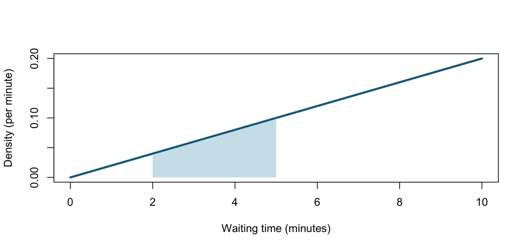

```r
curve(x / 50, from = 0, to = 10, lwd = 3, col = "#176B87",
      xlab = "Waiting time (minutes)", ylab = "Density (per minute)")
polygon(c(2, 2, 5, 5), c(0, 2 / 50, 5 / 50, 0),
        col = "#CEE3EB", border = NA)
curve(x / 50, add = TRUE, lwd = 3, col = "#176B87")
```

**Ask:** Why is an interval near 8 more likely than an equally wide interval near 2 under this model? Contrast that with the uniform model.

## 3. Normal density, cumulative probability, and a near-tie

Use the hypothetical forecast $V\sim\operatorname{Norm}(3,5)$, with margin measured in percentage points and **standard deviation** 5.

**Predict:** Should the win probability exceed one half? Does a density at zero directly answer a probability question?

```r
mu <- 3
sigma <- 5
density_at_zero <- dnorm(0, mean = mu, sd = sigma)
p_win <- pnorm(0, mean = mu, sd = sigma, lower.tail = FALSE)
p_near <- pnorm(1, mu, sigma) - pnorm(-1, mu, sigma)
p_at_or_below_zero <- pnorm(0, mean = mu, sd = sigma)
data.frame(quantity = c("Density at zero (per pp)", "P(V > 0)",
                         "P(-1 <= V <= 1)"),
           value = c(density_at_zero, p_win, p_near))
```

```
                  quantity      value
1 Density at zero (per pp) 0.06664492
2                 P(V > 0) 0.72574688
3          P(-1 <= V <= 1) 0.13272286
```

```r
epsilon <- c(.5, .1, .01)
near_tie <- data.frame(
  epsilon = epsilon,
  exact = pnorm(epsilon, mu, sigma) - pnorm(-epsilon, mu, sigma),
  rectangle = 2 * epsilon * density_at_zero
)
near_tie$probability_per_unit_width <- near_tie$exact / (2 * epsilon)
near_tie
```

```
  epsilon       exact   rectangle probability_per_unit_width
1    0.50 0.066573887 0.066644921                 0.06657389
2    0.10 0.013328415 0.013328984                 0.06664208
3    0.01 0.001332898 0.001332898                 0.06664489
```

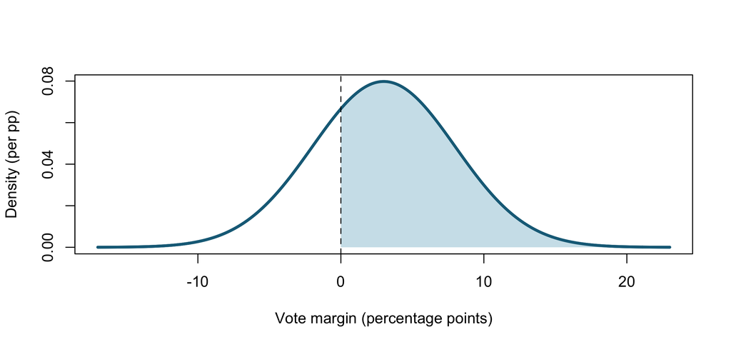

```r
x <- seq(mu - 4 * sigma, mu + 4 * sigma, length.out = 801)
plot(x, dnorm(x, mu, sigma), type = "l", col = "#176B87", lwd = 3,
     xlab = "Vote margin (percentage points)", ylab = "Density (per pp)")
z <- seq(0, max(x), length.out = 401)
polygon(c(0, z, max(z)), c(0, dnorm(z, mu, sigma), 0),
        col = "#CEE3EB", border = NA)
lines(x, dnorm(x, mu, sigma), col = "#176B87", lwd = 3)
abline(v = 0, lty = 2)
```

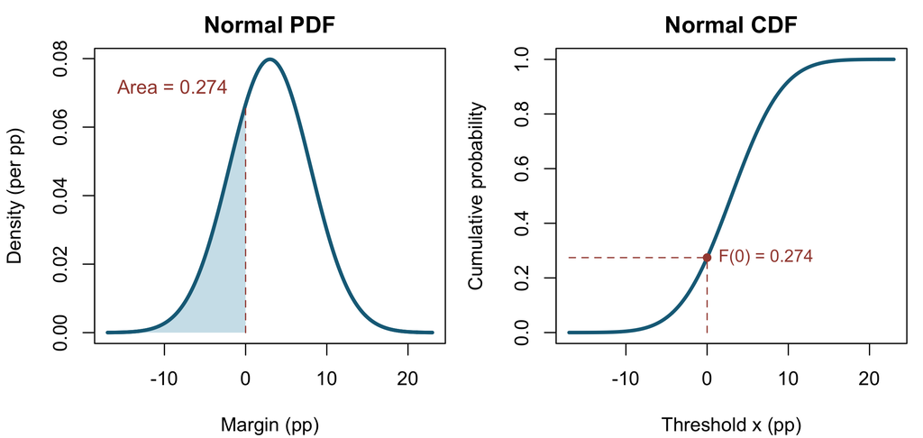

```r
# The same lower-tail probability as PDF area and CDF height.
old_par <- par(no.readonly = TRUE)
par(mfrow = c(1, 2), mar = c(4.1, 4.1, 2.1, .7))
plot(x, dnorm(x, mu, sigma), type = "l", col = "#176B87", lwd = 3,
     xlab = "Margin (pp)", ylab = "Density (per pp)", main = "Normal PDF")
z <- seq(min(x), 0, length.out = 401)
polygon(c(min(z), z, 0), c(0, dnorm(z, mu, sigma), 0),
        col = "#CEE3EB", border = NA)
lines(x, dnorm(x, mu, sigma), col = "#176B87", lwd = 3)
segments(0, 0, 0, dnorm(0, mu, sigma), lty = 2, col = "#A44A3F")
text(mu - 2.4 * sigma, dnorm(mu, mu, sigma) * .9,
     sprintf("Area = %.3f", p_at_or_below_zero), col = "#A44A3F")
plot(x, pnorm(x, mu, sigma), type = "l", col = "#176B87", lwd = 3,
     ylim = c(0, 1), xlab = "Threshold x (pp)",
     ylab = "Cumulative probability", main = "Normal CDF")
segments(min(x), p_at_or_below_zero, 0, p_at_or_below_zero,
         lty = 2, col = "#A44A3F")
segments(0, 0, 0, p_at_or_below_zero, lty = 2, col = "#A44A3F")
points(0, p_at_or_below_zero, pch = 16, col = "#A44A3F")
text(0, p_at_or_below_zero, sprintf("F(0) = %.3f", p_at_or_below_zero),
     pos = 4, col = "#A44A3F", cex = .9)
```

```r
par(old_par)

# Now vary the mean, keeping SD and the victory threshold fixed.
mean_grid <- seq(-15, 15, length.out = 601)
win_probability <- pnorm(0, mean = mean_grid, sd = sigma, lower.tail = FALSE)
selected_means <- c(-5, 0, 5)
selected_probabilities <- pnorm(selected_means / sigma)
data.frame(assumed_mean = selected_means,
           probability_of_victory = selected_probabilities)
```

```
  assumed_mean probability_of_victory
1           -5              0.1586553
2            0              0.5000000
3            5              0.8413447
```

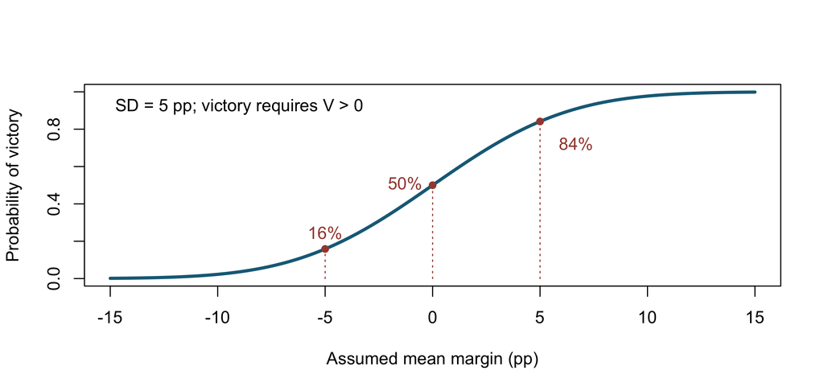

```r
plot(mean_grid, win_probability, type = "l", col = "#176B87", lwd = 3,
     ylim = c(0, 1), xlab = "Assumed mean margin (pp)",
     ylab = "Probability of victory")
segments(selected_means, 0, selected_means, selected_probabilities,
         lty = 3, col = "#A44A3F")
points(selected_means, selected_probabilities, pch = 16, col = "#A44A3F")
text(selected_means[1:2], selected_probabilities[1:2],
     sprintf("%.0f%%", 100 * selected_probabilities[1:2]),
     pos = c(3, 2), col = "#A44A3F")
text(selected_means[3] + .4, selected_probabilities[3] - .13,
     sprintf("%.0f%%", 100 * selected_probabilities[3]),
     pos = 4, col = "#A44A3F")
legend("topleft", sprintf("SD = %g pp; victory requires V > 0", sigma), bty = "n")
```

The near-tie probability tends to zero as the interval shrinks. Probability **divided by interval width** approaches the density. The normal curve extends beyond the plot; `pnorm()` includes its full tails.

On the CDF, the horizontal axis moves the **threshold** within the fixed $\operatorname{Norm}(3,5)$ distribution. On the final graph it changes the **assumed mean**, holding the victory threshold at zero. With SD 5, means $-5,0,5$ give victory probabilities of about 16%, 50%, and 84%.

The same increase in mean has a larger probability effect around an even contest than far out in either tail.

**Try:** Change only `sigma` to 10. Before running, predict the effect on the chance of a win when the mean remains positive.

## 4. Quantiles and simulation

A central 80% forecast interval leaves 10% in each tail. This interval describes the random margin under a given model. It is not a confidence interval for an unknown mean.

```r
set.seed(93004)
n_sim <- 50000
mu <- 3
sigma <- 5
interval <- qnorm(c(.10, .90), mean = mu, sd = sigma)
margins <- rnorm(n_sim, mean = mu, sd = sigma)
data.frame(quantile = c(.10, .90), margin = interval,
           cdf_check = pnorm(interval, mu, sigma))
```

```
  quantile    margin cdf_check
1      0.1 -3.407758       0.1
2      0.9  9.407758       0.9
```

```r
comparison <- data.frame(
  quantity = c("P(V > 0)", "P(-1 <= V <= 1)", "Mean", "Variance",
               "Inside central 80%"),
  exact = c(pnorm(0, mu, sigma, lower.tail = FALSE),
            pnorm(1, mu, sigma) - pnorm(-1, mu, sigma),
            mu, sigma^2, .8),
  simulated = c(mean(margins > 0), mean(margins >= -1 & margins <= 1),
                mean(margins), var(margins),
                mean(margins >= interval[1] & margins <= interval[2]))
)
comparison$absolute_difference <- abs(comparison$simulated - comparison$exact)
comparison
```

```
            quantity      exact simulated absolute_difference
1           P(V > 0)  0.7257469  0.725400        3.468822e-04
2    P(-1 <= V <= 1)  0.1327229  0.132700        2.285981e-05
3               Mean  3.0000000  3.005628        5.628145e-03
4           Variance 25.0000000 25.142743        1.427432e-01
5 Inside central 80%  0.8000000  0.799060        9.400000e-04
```

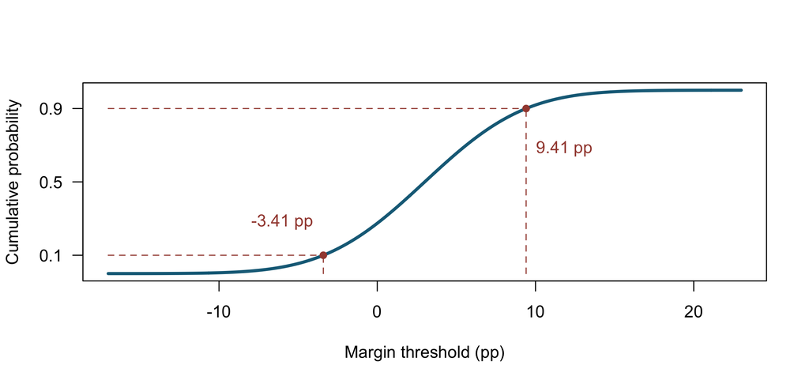

```r
x <- seq(mu - 4 * sigma, mu + 4 * sigma, length.out = 801)
probabilities <- c(.10, .90)
plot(x, pnorm(x, mu, sigma), type = "l", col = "#176B87", lwd = 3,
     ylim = c(0, 1), xlab = "Margin threshold (pp)",
     ylab = "Cumulative probability", yaxt = "n")
axis(2, at = c(.1, .5, .9), las = 1)
segments(min(x), probabilities, interval, probabilities,
         lty = 2, col = "#A44A3F")
segments(interval, 0, interval, probabilities, lty = 2, col = "#A44A3F")
points(interval, probabilities, pch = 16, col = "#A44A3F")
text(interval, c(.28, .68), sprintf("%.2f pp", interval),
     pos = c(2, 4), col = "#A44A3F")
```

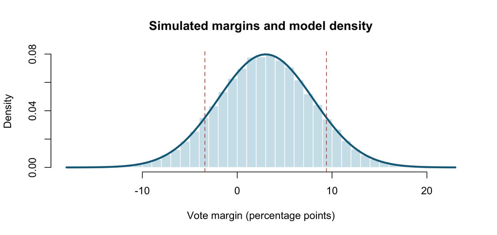

```r
hist(margins, probability = TRUE, breaks = 50, col = "#CEE3EB",
     border = "white", main = "Simulated margins and model density",
     xlab = "Vote margin (percentage points)")
curve(dnorm(x, mu, sigma), add = TRUE, lwd = 3, col = "#176B87")
abline(v = interval, lty = 2, col = "#A44A3F")
```

Read the CDF guides from probabilities .10 and .90 across to the curve, then down to the thresholds. `pnorm(interval, mu, sigma)` checks that `qnorm()` returned the requested thresholds.

`probability = TRUE` puts histogram **area** on the probability scale. More repetitions improve Monte Carlo precision. They do not make the forecast distribution narrower.

## 5. A discrete election and its normal approximation

Suppose exactly 200 people vote for A or B, independently, with probability 0.5 for A. Let $K$ count A’s votes. These are explicit toy-model assumptions.

**Predict:** Is an exact tie impossible? Does a strict victory have probability exactly one half when a tie has positive probability?

```r
set.seed(93005)
n_sim <- 50000
n_voters <- 200
p <- .5
mu_count <- n_voters * p
sd_count <- sqrt(n_voters * p * (1 - p))
tie_count <- n_voters / 2
counts <- rbinom(n_sim, size = n_voters, prob = p)

tie_exact <- dbinom(tie_count, n_voters, p)
tie_normal <- pnorm(tie_count + .5, mu_count, sd_count) -
              pnorm(tie_count - .5, mu_count, sd_count)
win_exact <- pbinom(tie_count, n_voters, p, lower.tail = FALSE)
win_normal <- pnorm(tie_count + .5, mu_count, sd_count, lower.tail = FALSE)
data.frame(event = c("Tie", "Strict victory"),
           binomial = c(tie_exact, win_exact),
           normal_with_correction = c(tie_normal, win_normal),
           simulated = c(mean(counts == tie_count), mean(counts > tie_count)))
```

```
           event   binomial normal_with_correction simulated
1            Tie 0.05634848             0.05637198   0.05814
2 Strict victory 0.47182576             0.47181401   0.47246
```

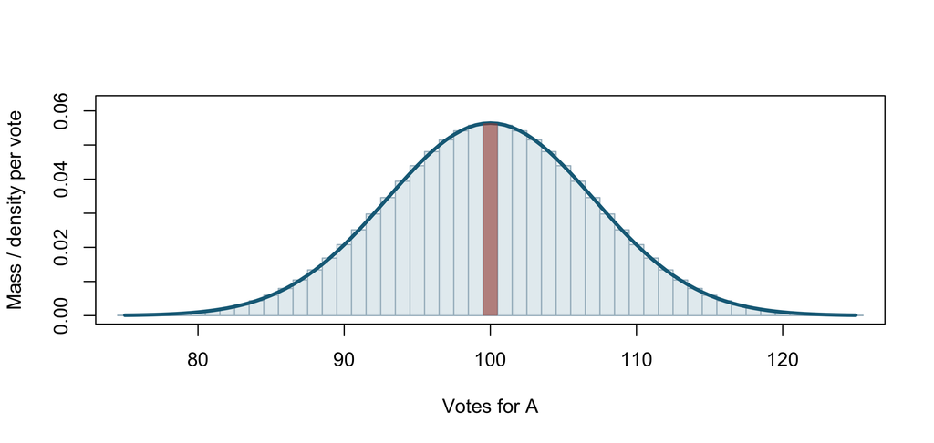

```r
k <- 75:125
plot(c(75, 125), c(0, .062), type = "n",
     xlab = "Votes for A", ylab = "Mass / density per vote")
rect(k - .5, 0, k + .5, dbinom(k, n_voters, p),
     col = "#E5EDF1", border = "#A6BBC7")
curve(dnorm(x, mu_count, sd_count), add = TRUE, lwd = 3, col = "#176B87")
z <- seq(tie_count - .5, tie_count + .5, length.out = 101)
polygon(c(min(z), z, max(z)), c(0, dnorm(z, mu_count, sd_count), 0),
        col = adjustcolor("#A44A3F", .6), border = NA)
```

```r
# The same tie bin expressed in percentage-point margin units:
margin_mu <- 100 * (2 * p - 1)
margin_sd <- 200 * sd_count / n_voters
tie_from_margin <- pnorm(100 / n_voters, margin_mu, margin_sd) -
                   pnorm(-100 / n_voters, margin_mu, margin_sd)
c(tie_from_count_units = tie_normal, tie_from_margin_units = tie_from_margin)
```

```
 tie_from_count_units tie_from_margin_units
           0.05637198            0.05637198
```

Each PMF bar has width one vote, so its height and area have the same numerical value. A normal density has probability **over a bin**, not at a point. The tie bin is 99.5 to 100.5 votes. A strict victory begins at its upper boundary, 100.5.

The count and percentage-margin density heights have different units. Probabilities agree after transforming both the distribution and interval.

## 6. A continuous margin gives a discrete contract payoff

Continue with the **hypothetical** forecast $\operatorname{Norm}(3,5)$. A contract pays $2 if the candidate wins and zero otherwise. It costs $1.50. Ignore fees and interest. This is a probability example, not a description of a real market.

**Predict:** Does a probability of profit above one half guarantee positive expected profit?

```r
set.seed(93006)
n_sim <- 50000
mu <- 3
sigma <- 5
prize <- 2
price <- 1.50
margins <- rnorm(n_sim, mu, sigma)
win <- margins > 0
payout <- ifelse(win, prize, 0)
profit <- payout - price
p_win <- pnorm(0, mu, sigma, lower.tail = FALSE)
pmf <- data.frame(profit = c(-price, prize - price),
                  probability = c(1 - p_win, p_win))
pmf
```

```
  profit probability
1   -1.5   0.2742531
2    0.5   0.7257469
```

```r
data.frame(
  quantity = c("Expected profit", "Profit variance", "P(positive profit)"),
  exact = c(prize * p_win - price, prize^2 * p_win * (1 - p_win), p_win),
  simulated = c(mean(profit), var(profit), mean(profit > 0))
)
```

```
            quantity       exact  simulated
1    Expected profit -0.04850624 -0.0460400
2    Profit variance  0.79615338  0.7939362
3 P(positive profit)  0.72574688  0.7269800
```

```r
c(break_even_price = prize * p_win)
```

```
break_even_price
        1.451494
```

Keep each payout tied to its corresponding margin draw. Do not independently draw another win indicator. Subtracting a fixed price shifts all profits by the same amount and leaves their variance unchanged.

## 7. A finite population, its PMF, and its CDF

Four potential project partners have minimum acceptable payments of 5, 15, 15, and 45 points. Randomly choose one person with equal probability. This is a made-up teaching population, not the B2 dataset.

**Predict:** Are the three distinct minimum payments equally likely?

```r
costs <- c(5, 15, 15, 45)
values <- sort(unique(costs))
counts <- as.numeric(table(factor(costs, levels = values)))
probability <- counts / length(costs)
cdf <- cumsum(probability)
data.frame(value = values, count = counts, probability = probability, cdf = cdf)
```

```
  value count probability  cdf
1     5     1        0.25 0.25
2    15     2        0.50 0.75
3    45     1        0.25 1.00
```

```r
mu_cost <- sum(values * probability)
variance_cost <- sum((values - mu_cost)^2 * probability)
c(mean = mu_cost, population_variance = variance_cost,
  direct_variance = mean((costs - mean(costs))^2),
  R_sample_variance = var(costs))
```

```
               mean population_variance     direct_variance   R_sample_variance
                 20                 225                 225                 300
```

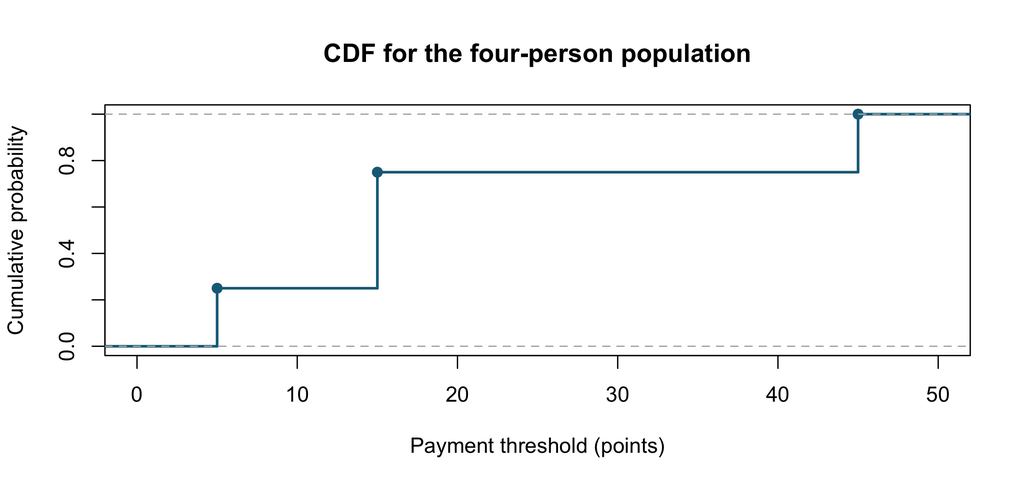

```r
plot(ecdf(costs), verticals = TRUE, do.points = TRUE,
     xlim = c(0, 50), col = "#176B87", lwd = 2,
     main = "CDF for the four-person population",
     xlab = "Payment threshold (points)", ylab = "Cumulative probability")
```

```r
c(at_most_15 = mean(costs <= 15), below_15 = mean(costs < 15))
```

```
at_most_15   below_15
      0.75       0.25
```

`ecdf(costs)` gives the exact CDF for a uniform draw from these four entries. Here we define those entries as our entire population. We make no claim about a larger population. R’s `var(costs)` uses denominator $N-1$; the finite-population variance here uses $N$.

## 8. The payoff against a mean partner and crossing CDFs

The project has an 80-point budget. Choose an offer before drawing a partner. If the offer meets their minimum, you retain the rest of the budget; otherwise you receive zero.

```r
set.seed(93008)
n_sim <- 50000
costs <- c(5, 15, 15, 45)
budget <- 80
earnings <- function(cost, offer) ifelse(cost <= offer, budget - offer, 0)
y15 <- earnings(costs, 15)
y45 <- earnings(costs, 45)
comparison <- data.frame(
  offer = c(15, 45),
  payoff_against_mean = c(earnings(mean(costs), 15),
                          earnings(mean(costs), 45)),
  expected_payoff = c(mean(y15), mean(y45)),
  population_variance = c(mean((y15 - mean(y15))^2),
                          mean((y45 - mean(y45))^2)),
  probability_above_20 = c(mean(y15 > 20), mean(y45 > 20)),
  probability_above_50 = c(mean(y15 > 50), mean(y45 > 50))
)
comparison
```

```
  offer payoff_against_mean expected_payoff population_variance
1    15                   0           48.75            792.1875
2    45                  35           35.00              0.0000
  probability_above_20 probability_above_50
1                 0.75                 0.75
2                 1.00                 0.00
```

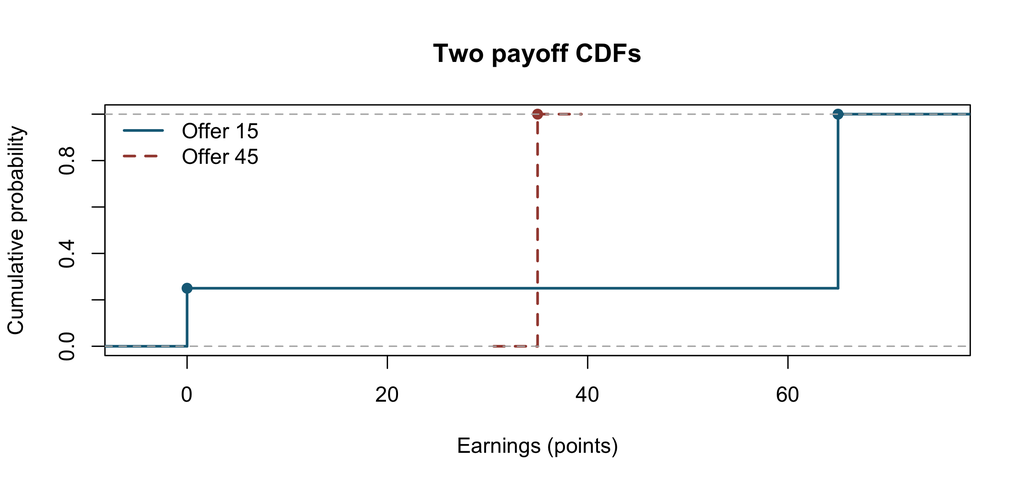

```r
plot(ecdf(y15), xlim = c(-5, 75), ylim = c(0, 1),
     verticals = TRUE, do.points = TRUE, col = "#176B87", lwd = 2,
     main = "Two payoff CDFs", xlab = "Earnings (points)",
     ylab = "Cumulative probability")
plot(ecdf(y45), add = TRUE, verticals = TRUE, do.points = TRUE,
     col = "#A44A3F", lty = 2, lwd = 2)
legend("topleft", c("Offer 15", "Offer 45"),
       col = c("#176B87", "#A44A3F"), lty = c(1, 2), lwd = 2, bty = "n")
```

```r
partners <- sample(costs, size = n_sim, replace = TRUE)
data.frame(offer = c(15, 45), exact = c(mean(y15), mean(y45)),
           simulated = c(mean(earnings(partners, 15)),
                         mean(earnings(partners, 45))))
```

```
  offer exact simulated
1    15 48.75   48.6317
2    45 35.00   35.0000
```

Offer 15 has higher expected earnings, but offer 45 is more likely to exceed 20 points. The ordering reverses at a 50-point threshold. The mean alone does not determine the whole distribution.

Drawing from the full four-person vector preserves the repeated value 15. Sampling the three distinct values uniformly would change the population.

## 9. A guided function and loop over offers

This example calculates each offer’s payoff for every possible partner. There is no randomness in that calculation. Simulation appears in Demo 8.

**Before running:** Trace the loop once with an offer of 15. Identify which objects describe an offer, a partner, a vector of payoffs, and a table row.

```r
costs <- c(5, 15, 15, 45)
summarize_project <- function(costs, budget = 80) {
  result <- data.frame(offer = 0:budget, acceptance = NA_real_,
                       expected = NA_real_, variance = NA_real_)
  for (i in seq_len(nrow(result))) {
    offer <- result$offer[i]
    accepted <- costs <= offer
    payoff <- ifelse(accepted, budget - offer, 0)
    result$acceptance[i] <- mean(accepted)
    result$expected[i] <- mean(payoff)
    result$variance[i] <- mean((payoff - mean(payoff))^2)
  }
  result
}
offers <- summarize_project(costs)
offers[offers$offer %in% c(0, 5, 15, 25, 45, 80), ]
```

```
   offer acceptance expected  variance
1      0       0.00     0.00    0.0000
6      5       0.25    18.75 1054.6875
16    15       0.75    48.75  792.1875
26    25       0.75    41.25  567.1875
46    45       1.00    35.00    0.0000
81    80       1.00     0.00    0.0000
```

```r
best <- abs(offers$expected - max(offers$expected)) < 1e-10
offers[best, ]
```

```
   offer acceptance expected variance
16    15       0.75    48.75 792.1875
```

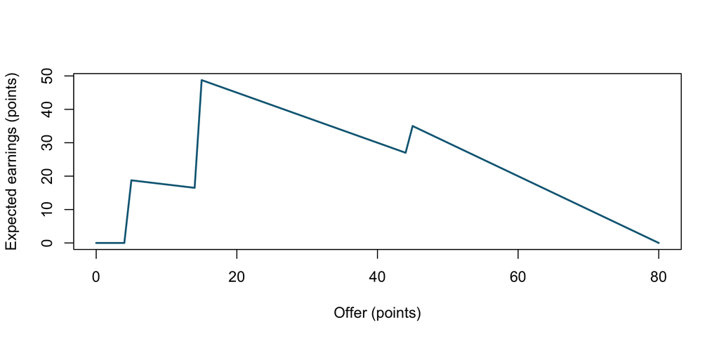

```r
plot(offers$offer, offers$expected, type = "l",
     col = "#176B87", lwd = 2,
     xlab = "Offer (points)", ylab = "Expected earnings (points)")
```

`NA_real_` reserves numeric cells that the loop will fill. The function returns its last expression, `result`. Row index `i` differs from the offer: row 1 corresponds to offer 0. Store the complete table, but display only the rows needed for interpretation.

**Try:** Give a second toy population to the same function. Which quantities change? In B2, use the supplied data and your own derived payoff formulas.

## References

Speegle and Clair, [*Probability, Statistics, and Data*, Chapter 4](https://probstatsdata.com/continuousrandomvariables.html), especially Sections 4.1-4.4.2. These political examples, figures, and code are original course demonstrations. Use `?dnorm`, `?pnorm`, `?qnorm`, `?rnorm`, `?dbinom`, or `?ecdf` for the installed R documentation.